# Parametric Survival Models in Stan

Eren Metin Elci

2018-11-05

# Monotone splines

> Ramsay, James O. “Monotone regression splines in action.” Statistical science 3.4 (1988): 425-441.

$$h_0(t;\gamma;k) = \sum_{j=1}^{m} M_j(t;k)\gamma_j$$

$$I_j{t;k} = \int_{0}^{t} M_j(u;k) \rm{d}u$$

$$H_0(t;\gamma;k) = \sum_{j=1}^{m} I_j(t;k)\gamma_j$$

## m-Splines

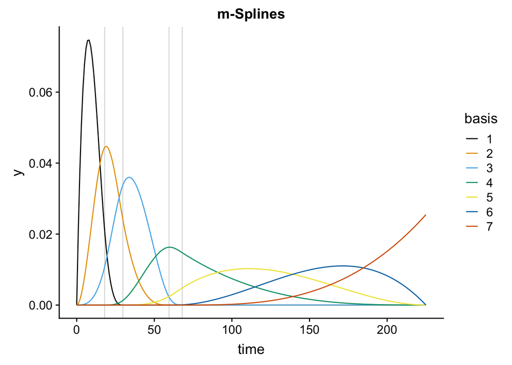

### Random linear combinations

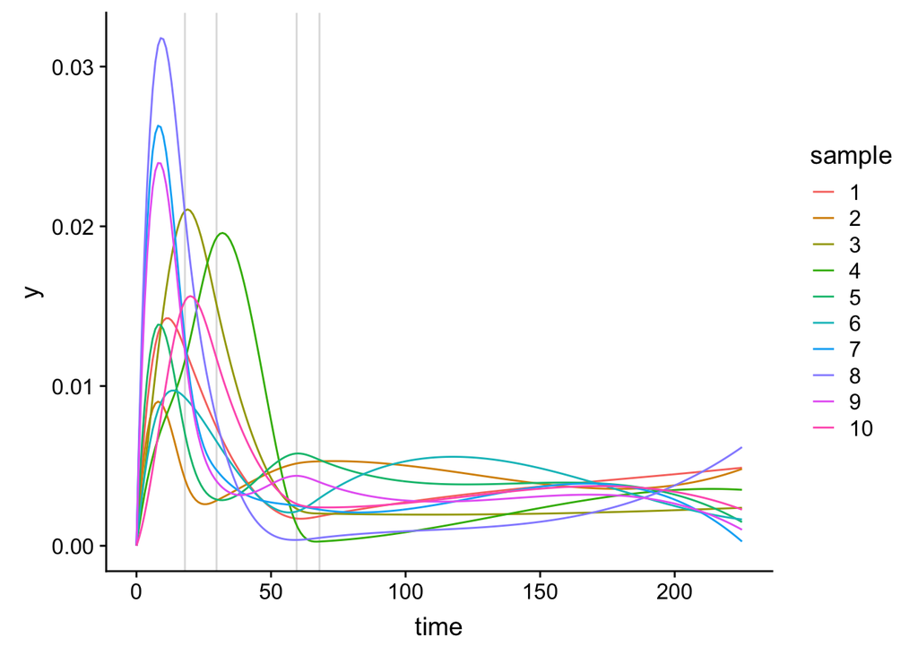

## i-Splines

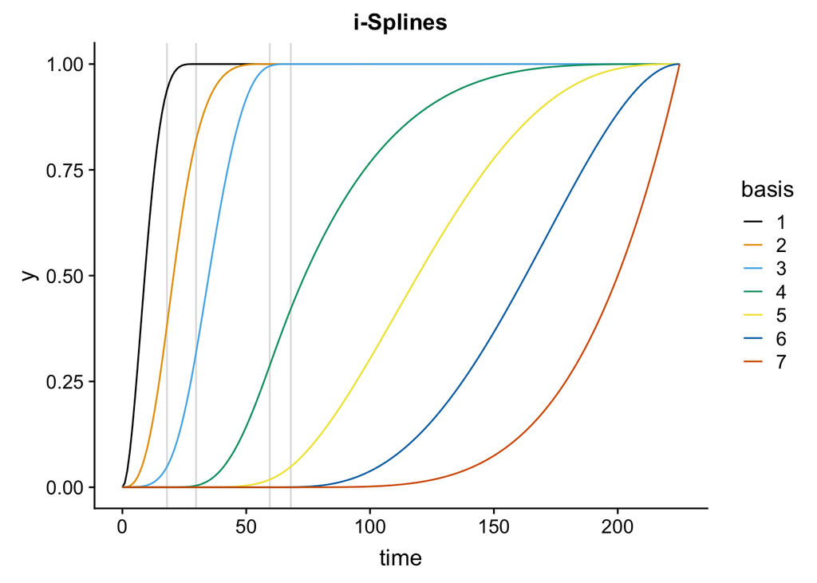

### Random linear combinations

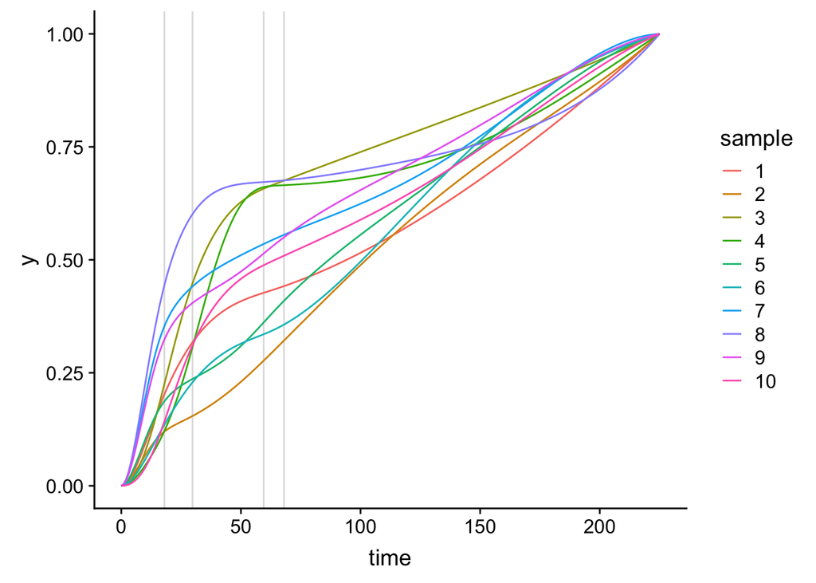

# Stan model

```stan
data {
    int<lower=0> N_uncensored;
    int<lower=0> N_censored;
    int<lower=1> m;
    int<lower=1> NC;
    matrix[N_censored,NC] X_censored;
    matrix[N_uncensored,NC] X_uncensored;
    matrix[N_uncensored,m] m_spline_basis_evals_uncensored;
    matrix[N_uncensored,m] i_spline_basis_evals_uncensored;
    matrix[N_censored,m] i_spline_basis_evals_censored;
    int<lower=0, upper=1> condition;
}
parameters {
    simplex[m] gammas;
    real<lower=0> sigma;
    vector[NC] betas;
    real intercept;
}
model {
    betas ~ normal(0,1);
    intercept   ~ normal(0,5);
    sigma ~ normal(0,1);
    if(condition) {
        target += -(i_spline_basis_evals_censored*gammas) .* exp(X_censored*betas + intercept);
        target += -(i_spline_basis_evals_uncensored*gammas) .* exp(X_uncensored*betas + intercept);
        target +=  log(m_spline_basis_evals_uncensored*gammas) + X_uncensored*betas + intercept;
    }
}
```

# Inference

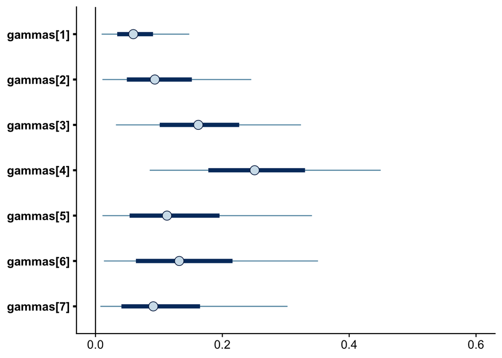

# Survival curves

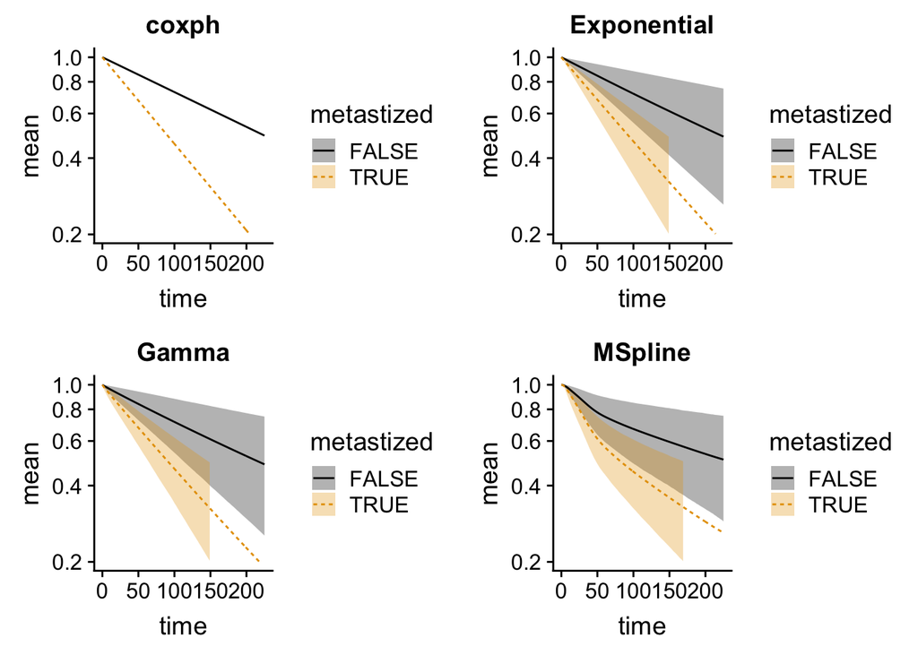

# Brier score

> Gerds, Thomas A., and Martin Schumacher. “Consistent estimation of the expected Brier score in general survival models with right‐censored event times.” Biometrical Journal 48.6 (2006): 1029-1040. APA

> pec: Prediction Error Curves for Risk Prediction Models in Survival Analysis

$$\rm{MSE}(t,\hat{\pi}_n, S) = \int_{\mathbb{R}^d} \int_0^\infty \left( \mathbf{1}_{\{s>t\}} - \hat{\pi}_n(t\vert \mathbf{x})\right)^2 F(ds\vert \mathbf{x}) H(d\mathbf{x})$$

$$\rm{WRSS}(t, \hat{\pi}_n, \hat{G}_n) = \frac{1}{n} \sum_{i=1}^n \left(\mathbf{1}_{\{T_i > t\}} -\hat{\pi}_n(t \vert \mathbf{x}_i)\right)^2
\omega(t, \hat{G}_n, \mathbf{x}_i, T_i, \Delta_i)$$

$$\omega(t, \hat{G}_n, \mathbf{x}_i, T_i, \Delta_i) = \frac{\mathbf{1}_{\{T_i \leq t\}} \Delta_i}{\hat{G}_n(T_i \vert \mathbf{x}_i)} + \frac{\mathbf{1}_{\{T_i > t\}}}{\hat{G}_n(t \vert \mathbf{x}_i)}$$

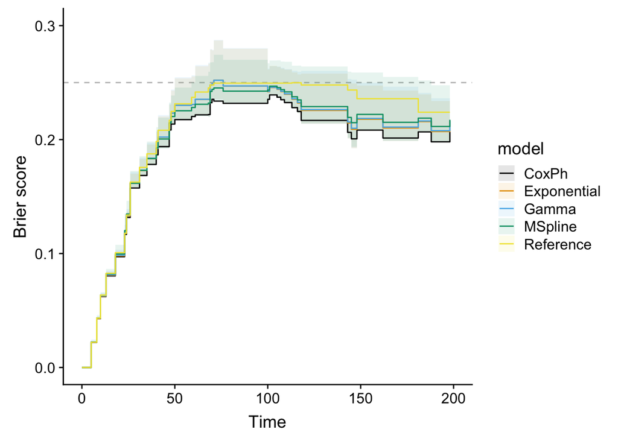

# (Conditioned) Posterior predictive checks

## Comparing distributions

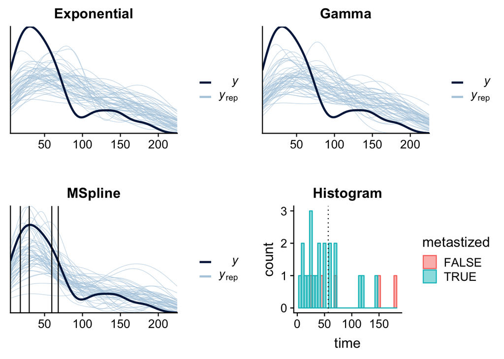

## Mean

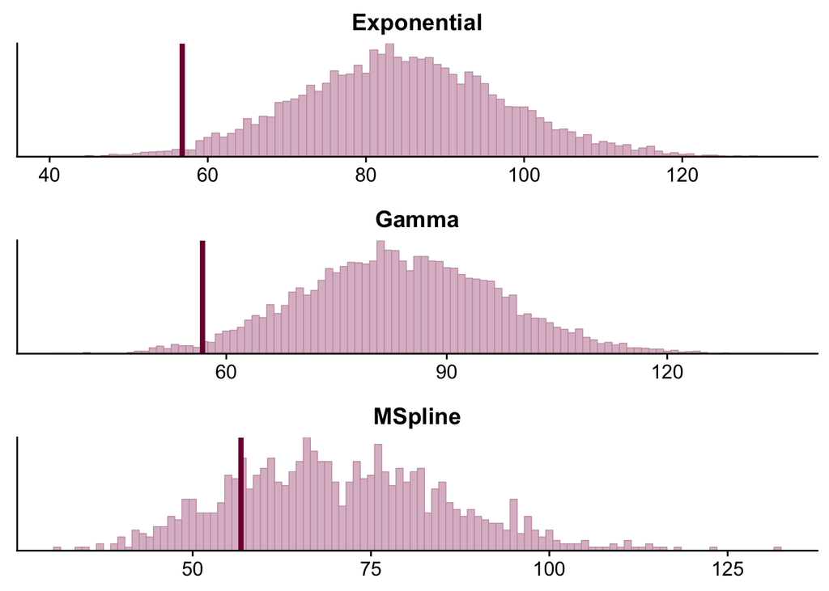

## Median

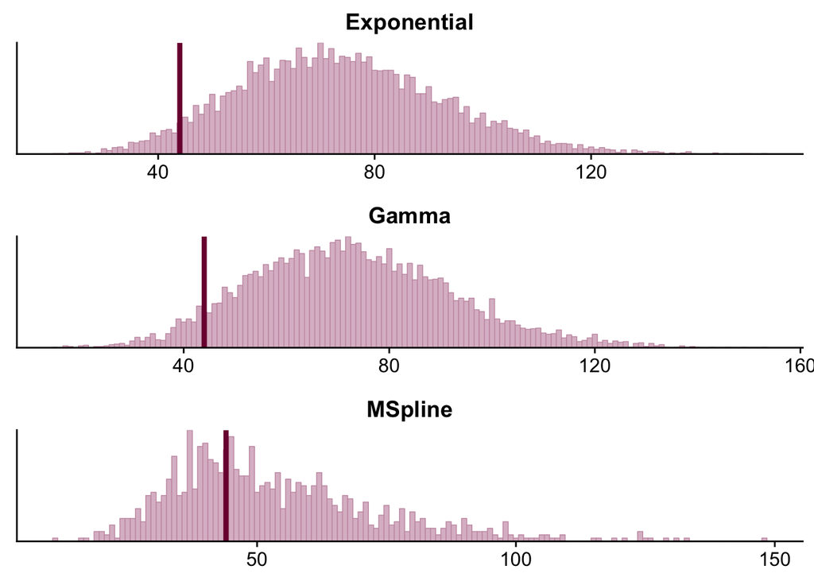

## Standard deviation

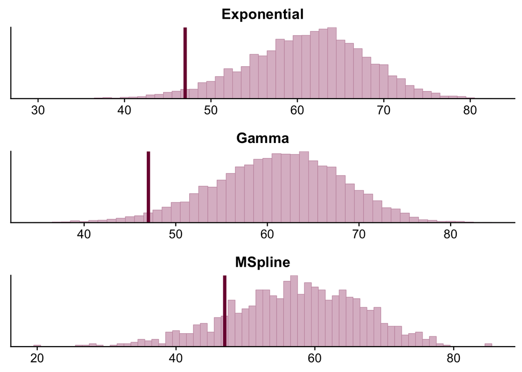

## Min

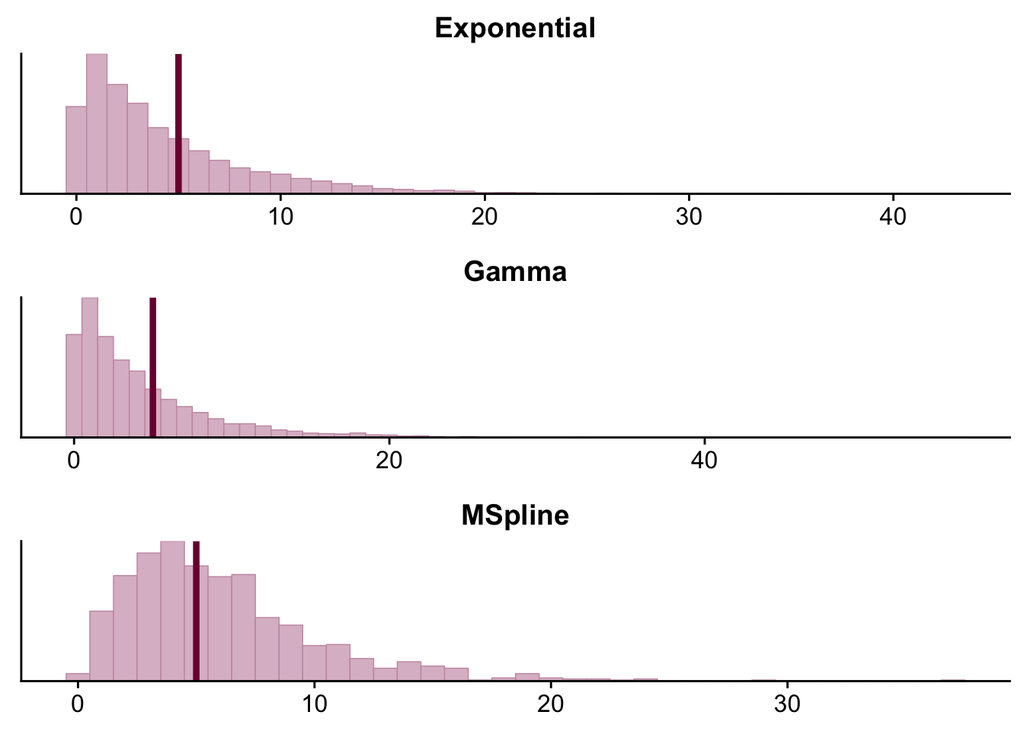

## Max

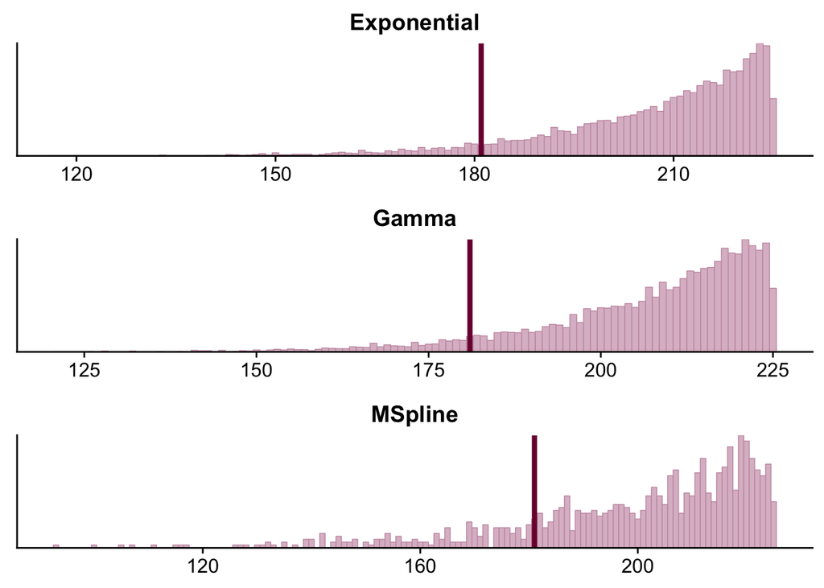

## Non-parametric Kaplan-Meier estimator

$$\widehat{S}(t) = \prod_{t_i \leq t} \left( 1- \frac{d_i}{n_i} \right)$$

- $t_i$: Time at which at least one event happened
- $d_i$: Number of events (e.g. deaths) that happened at time $t_i$
- $n_i$: Number of individuals known to survive at time $t_i$ (i.e. have not yet had an event or been censored)

Below we use $\widehat{S}(70)$ as a statistics for posterior predictive checking. Note that,

- We only vary the uncensored cases (i.e. we replace them with posterior predictive samples)
- We keep the censored cases fixed over all replications (our generative model does not contain sufficient structure to explain the censoring process)

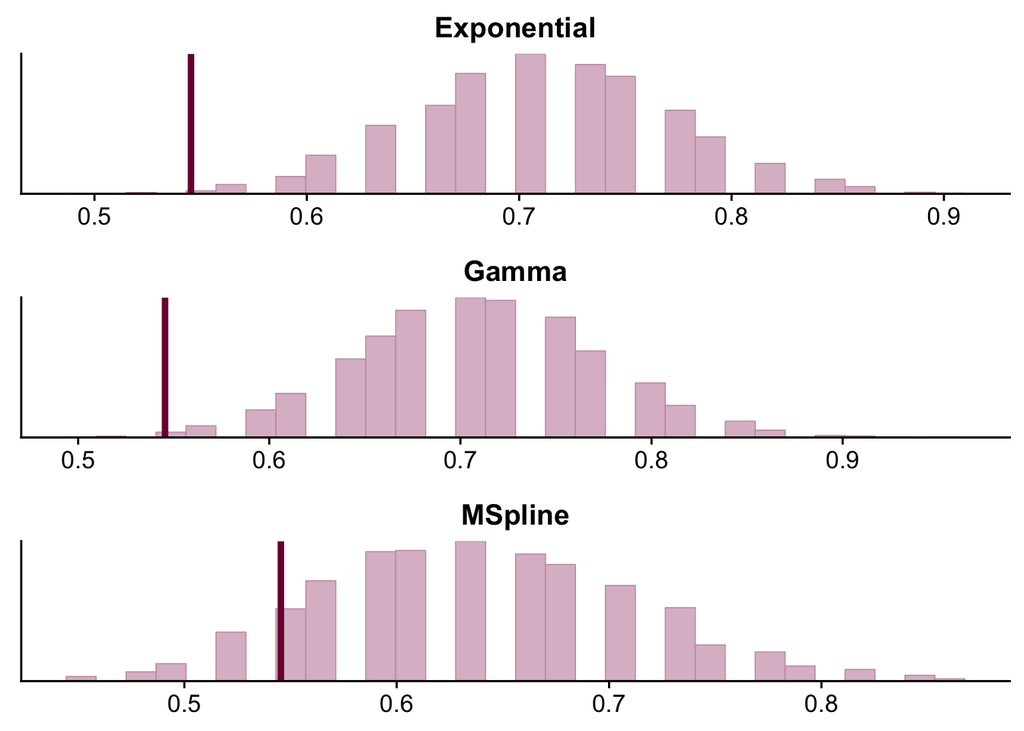

# Outlook

## Survival models in rstanarm

### Pull request

https://github.com/stan-dev/rstanarm/pull/323

### Background discussion

https://github.com/stan-dev/rstanarm/issues/280

### Example

```r
library(devtools)
dev_mode(on=T)
library(rstanarm)
fit_stansurv <- stan_surv(Surv(time, event)~metastized, data=df)
dev_mode(on=F)
```

```
## # A tibble: 7 x 3
##   term            estimate std.error
##   <chr>              <dbl>     <dbl>
## 1 metastized        0.0884    0.378
## 2 m-splines-coef1   0.0335    0.0332
## 3 m-splines-coef2   0.133     0.0902
## 4 m-splines-coef3   0.486     0.220
## 5 m-splines-coef4   0.175     0.162
## 6 m-splines-coef5   0.200     0.175
## 7 m-splines-coef6   0.214     0.199
```